# Boosting Spam

Shan Chen

4/27/2020

# Old Tasks with other models:

# Data

```r
dataDir <- "/Users/shawnchen/Desktop/rzhw"
dataFile <- "SpamData.csv"
spam.df <- read.csv(file.path(dataDir,dataFile))
head(spam.df)
```

```
##    C01  C02  C03 C04  C05  C06  C07  C08  C09  C10  C11  C12  C13  C14  C15
## 1 0.21 0.28 0.50   0 0.14 0.28 0.21 0.07 0.00 0.94 0.21 0.79 0.65 0.21 0.14
## 2 0.06 0.00 0.71   0 1.23 0.19 0.19 0.12 0.64 0.25 0.38 0.45 0.12 0.00 1.75
## 3 0.00 0.00 0.00   0 0.63 0.00 0.31 0.63 0.31 0.63 0.31 0.31 0.31 0.00 0.00
## 4 0.00 0.00 0.00   0 0.63 0.00 0.31 0.63 0.31 0.63 0.31 0.31 0.31 0.00 0.00
## 5 0.00 0.00 0.00   0 1.85 0.00 0.00 1.85 0.00 0.00 0.00 0.00 0.00 0.00 0.00
## 6 0.00 0.00 0.00   0 1.92 0.00 0.00 0.00 0.00 0.64 0.96 1.28 0.00 0.00 0.00
##    C16  C17  C18  C19  C20  C21 C22  C23  C24 C25 C26 C27 C28 C29 C30 C31 C32
## 1 0.14 0.07 0.28 3.47 0.00 1.59   0 0.43 0.43   0   0   0   0   0   0   0   0
## 2 0.06 0.06 1.03 1.36 0.32 0.51   0 1.16 0.06   0   0   0   0   0   0   0   0
## 3 0.31 0.00 0.00 3.18 0.00 0.31   0 0.00 0.00   0   0   0   0   0   0   0   0
## 4 0.31 0.00 0.00 3.18 0.00 0.31   0 0.00 0.00   0   0   0   0   0   0   0   0
## 5 0.00 0.00 0.00 0.00 0.00 0.00   0 0.00 0.00   0   0   0   0   0   0   0   0
## 6 0.96 0.00 0.32 3.85 0.00 0.64   0 0.00 0.00   0   0   0   0   0   0   0   0
##   C33 C34 C35 C36  C37 C38 C39  C40 C41 C42  C43 C44  C45  C46 C47 C48  C49
## 1   0   0   0   0 0.07   0   0 0.00   0   0 0.00   0 0.00 0.00   0   0 0.00
## 2   0   0   0   0 0.00   0   0 0.06   0   0 0.12   0 0.06 0.06   0   0 0.01
## 3   0   0   0   0 0.00   0   0 0.00   0   0 0.00   0 0.00 0.00   0   0 0.00
## 4   0   0   0   0 0.00   0   0 0.00   0   0 0.00   0 0.00 0.00   0   0 0.00
## 5   0   0   0   0 0.00   0   0 0.00   0   0 0.00   0 0.00 0.00   0   0 0.00
## 6   0   0   0   0 0.00   0   0 0.00   0   0 0.00   0 0.00 0.00   0   0 0.00
##     C50 C51   C52   C53   C54   C55 C56  C57 IsSpam
## 1 0.132   0 0.372 0.180 0.048 5.114 101 1028      1
## 2 0.143   0 0.276 0.184 0.010 9.821 485 2259      1
## 3 0.137   0 0.137 0.000 0.000 3.537  40  191      1
## 4 0.135   0 0.135 0.000 0.000 3.537  40  191      1
## 5 0.223   0 0.000 0.000 0.000 3.000  15   54      1
## 6 0.054   0 0.164 0.054 0.000 1.671   4  112      1
```

# Penalized Regression

Start with penalized regression

Build the data

```r
names(spam.df)
```

```
##  [1] "C01"    "C02"    "C03"    "C04"    "C05"    "C06"    "C07"    "C08"
##  [9] "C09"    "C10"    "C11"    "C12"    "C13"    "C14"    "C15"    "C16"
## [17] "C17"    "C18"    "C19"    "C20"    "C21"    "C22"    "C23"    "C24"
## [25] "C25"    "C26"    "C27"    "C28"    "C29"    "C30"    "C31"    "C32"
## [33] "C33"    "C34"    "C35"    "C36"    "C37"    "C38"    "C39"    "C40"
## [41] "C41"    "C42"    "C43"    "C44"    "C45"    "C46"    "C47"    "C48"
## [49] "C49"    "C50"    "C51"    "C52"    "C53"    "C54"    "C55"    "C56"
## [57] "C57"    "IsSpam"
```

```r
with(spam.df,table(IsSpam))
```

```
## IsSpam
##    0    1
## 2788 1812
```

```r
numPreds <- ncol(spam.df)-1
spam.x <- data.matrix(spam.df[,1:numPreds])
spam.y <- data.matrix(spam.df[,-(1:numPreds)])
```

```r
lambda.grid <- 10^seq(-5,1,length=50)
ridge.cv <- cv.glmnet(spam.x,spam.y,
                      lambda=lambda.grid,
                      family="binomial",
                      type.measure="class",
                      alpha=0)
```

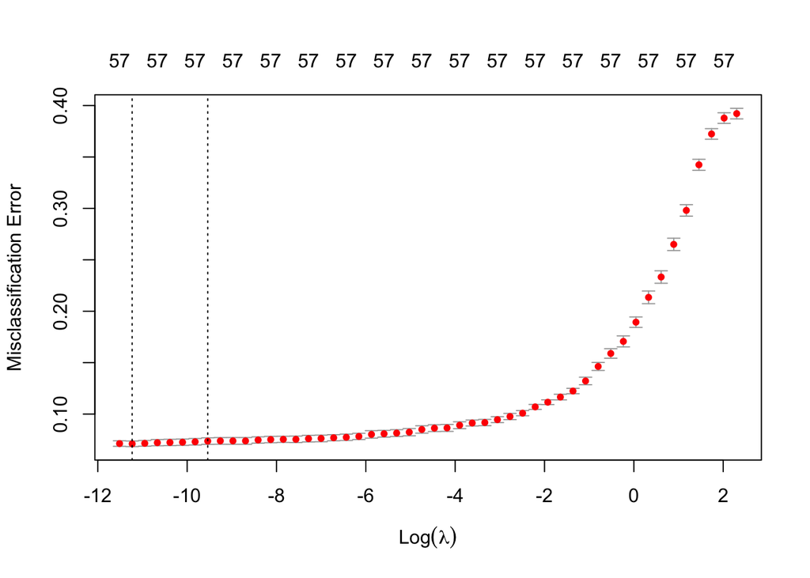

```r
plot(ridge.cv)
```

```r
lambda.opt <- ridge.cv$lambda.1se
id <- with(ridge.cv,which(lambda==lambda.opt))
(err.ridge <- with(ridge.cv,cvm[id]))
```

```
## [1] 0.07369565
```

Repeat with Lasso

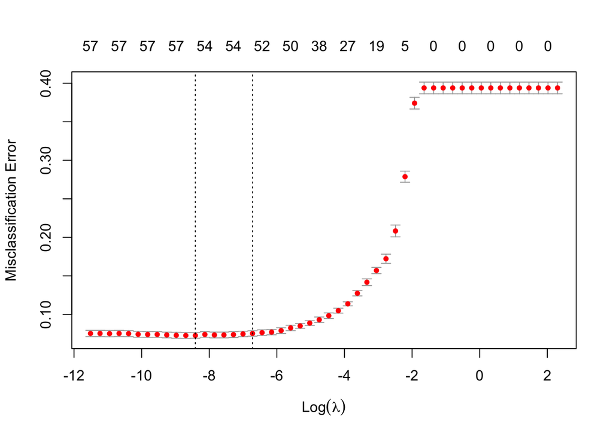

```r
lasso.cv <- cv.glmnet(spam.x,spam.y,
                      lambda=lambda.grid,
                      family="binomial",
                      type.measure="class",
                      alpha=1)
plot(lasso.cv)
```

```r
lambda.opt <- lasso.cv$lambda.1se
id <- with(lasso.cv,which(lambda==lambda.opt))
(err.lasso <- with(lasso.cv,cvm[id]))
```

```
## [1] 0.07521739
```

```r
lasso.cv$nzero[id]
```

```
## s32
##  53
```

```r
dim(spam.x)
```

```
## [1] 4600   57
```

```r
lasso.opt <- glmnet(spam.x,spam.y,
                    lambda=lambda.opt,
                    family="binomial",
                    alpha=1)
coefs <- coefficients(lasso.opt)
lassoPreds <- which(coefs != 0)
(lassoPreds <- lassoPreds[-1]-1)
```

```
##  [1]  1  2  3  4  5  6  7  8  9 10 11 12 14 15 16 17 18 19 20 21 22 23 24 25 26
## [26] 27 28 29 30 31 33 35 36 37 38 39 40 41 42 43 44 45 46 47 48 49 50 51 52 53
## [51] 54 56 57
```

What the heck, let’s build a logistic regression model

```r
spam.red.df <- spam.df[,c(lassoPreds,ncol(spam.df))]
## Build a train/test
N <- nrow(spam.red.df)
train <- sample(1:N,N/2,rep=F)
train.df <- spam.red.df[train,]
test.df <- spam.red.df[-train,]
mod.log <- glm(IsSpam ~ ., data=train.df,
               family="binomial")
preds <- predict(mod.log,newdata=test.df,type="response") > 0.5
with(test.df,table(IsSpam,preds))
```

```
##       preds
## IsSpam FALSE TRUE
##      0  1299   86
##      1   100  815
```

```r
with(test.df,mean((IsSpam==1) != preds))
```

```
## [1] 0.08086957
```

```r
numFolds <- 10
N <- nrow(spam.df)
folds <- sample(1:numFolds,N,rep=T)
errs <- numeric(numFolds)
for(fold in 1:numFolds){
  train.df <- spam.red.df[folds != fold,]
  test.df <- spam.red.df[folds == fold,]
  mod.log <- glm(IsSpam ~ .,
                 data=train.df,
                 family="binomial")
  preds <- predict(mod.log,
                   newdata=test.df,type="response") > 0.5
  errs[fold] <- with(test.df,mean((IsSpam==1) != preds))
}
c(mean(errs),sd(errs))
```

```
## [1] 0.07397616 0.01053963
```

```r
errs
```

```
##  [1] 0.05895197 0.07096774 0.07974138 0.06278027 0.08995816 0.06607930
##  [7] 0.07415730 0.07021277 0.07657658 0.09033613
```

```r
(err.log <- mean(errs))
```

```
## [1] 0.07397616
```

```r
c(err.ridge,err.lasso,err.log)
```

```
## [1] 0.07369565 0.07521739 0.07397616
```

# KNN

Check to see if the data are scaled

```r
summary(apply(spam.x,2,mean))
```

```
##      Min.   1st Qu.    Median      Mean   3rd Qu.      Max.
##   0.00545   0.06485   0.10287   6.15077   0.23947 283.29043
```

Nope

```r
spam.x <- scale(spam.x)
summary(apply(spam.x,2,mean))
```

```
##       Min.    1st Qu.     Median       Mean    3rd Qu.       Max.
## -4.738e-17 -1.329e-17 -4.334e-18 -4.007e-18  7.814e-18  4.167e-17
```

Much better

```r
N <- nrow(spam.x)
kVal <- 10
knnERR_SE <- function(kVal,numFolds=10){
  folds <- sample(1:numFolds,N,rep=T)
  errs <- numeric(numFolds)
  for(fold in 1:numFolds){
    train.x <- spam.x[folds != fold,]
    train.y <- spam.y[folds != fold]
    test.x <- spam.x[folds == fold,]
    test.y <-  spam.y[folds == fold]
    mod.knn <- knn(train.x,test.x,train.y,k=kVal)
    length(mod.knn)
    length(test.y)
    table(mod.knn,test.y)
    errs[fold] <- mean(mod.knn != test.y)
  }
  c(mean(errs),sd(errs))
}
## just the M
knnERR <- function(kVal,numFolds=10){ knnERR_SE(kVal,numFolds)[1]}

knnERR(1)
```

```
## [1] 0.08599757
```

```r
knnERR(4)
```

```
## [1] 0.1033942
```

```r
knnERR(10)
```

```
## [1] 0.0948161
```

```r
knnERR(20)
```

```
## [1] 0.0978136
```

```r
knnERR(30)
```

```
## [1] 0.1063573
```

```r
maxK <- 20
kVals <- 1:maxK
allErrs <- map_dbl(kVals,knnERR)
```

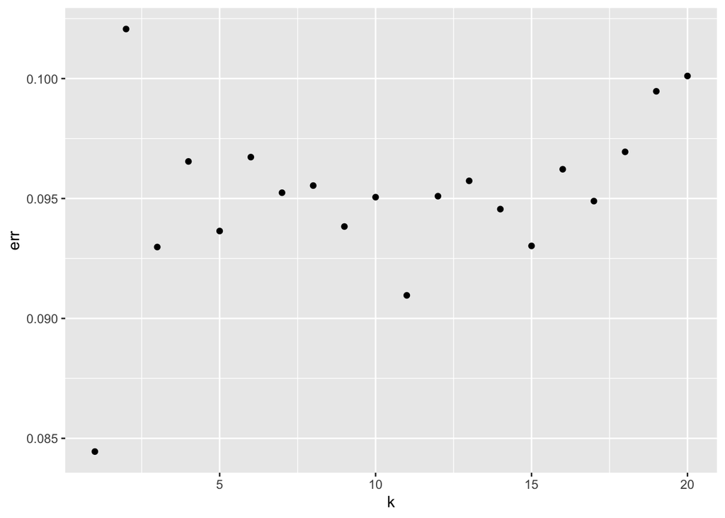

```r
data.frame(k=kVals,err=allErrs) %>%
  ggplot()+
  geom_point(aes(k,err))
```

KNN appears to be having a real hard time. Part of the problem is the large number of predictors.

```r
min(allErrs)
```

```
## [1] 0.08444856
```

This error rate is not competitive with what we saw earlier, and its not consistently even close to other models’ error rate.

```r
c(err.ridge,err.lasso,err.log)
```

```
## [1] 0.07369565 0.07521739 0.07397616
```

Now lets move on to ADA Boosting: #ADABOOSTING:

```r
spam.df1 <- spam.df %>%
  mutate(class=ifelse(IsSpam > 0,1,0))%>%
  select(-IsSpam)
with(spam.df1,table(class))
```

```
## class
##    0    1
## 2788 1812
```

```r
data.df <- spam.df1
N <- nrow(data.df)
train <- sample(1:N,N/2,rep=F)
train.df <- data.df[train,]
test.df <- data.df[-train,]
with(train.df,table(class))
```

```
## class
##    0    1
## 1420  880
```

```r
names(test.df)
```

```
##  [1] "C01"   "C02"   "C03"   "C04"   "C05"   "C06"   "C07"   "C08"   "C09"
## [10] "C10"   "C11"   "C12"   "C13"   "C14"   "C15"   "C16"   "C17"   "C18"
## [19] "C19"   "C20"   "C21"   "C22"   "C23"   "C24"   "C25"   "C26"   "C27"
## [28] "C28"   "C29"   "C30"   "C31"   "C32"   "C33"   "C34"   "C35"   "C36"
## [37] "C37"   "C38"   "C39"   "C40"   "C41"   "C42"   "C43"   "C44"   "C45"
## [46] "C46"   "C47"   "C48"   "C49"   "C50"   "C51"   "C52"   "C53"   "C54"
## [55] "C55"   "C56"   "C57"   "class"
```

```r
numTrees <- 200
theShrinkage <- 1
theDepth <- 2
mod.gbm <- gbm(class ~ .,
               data=train.df,
               distribution="adaboost",
               shrinkage=theShrinkage,
               n.trees=numTrees,
               interaction.depth = theDepth)
```

```r
numTreesPred <- 100
prob.gbm <- predict(mod.gbm,
                    newdata=test.df,
                    n.trees=100,type="response")
pred.gbm <- ifelse(prob.gbm > 0.5,1,0)
```

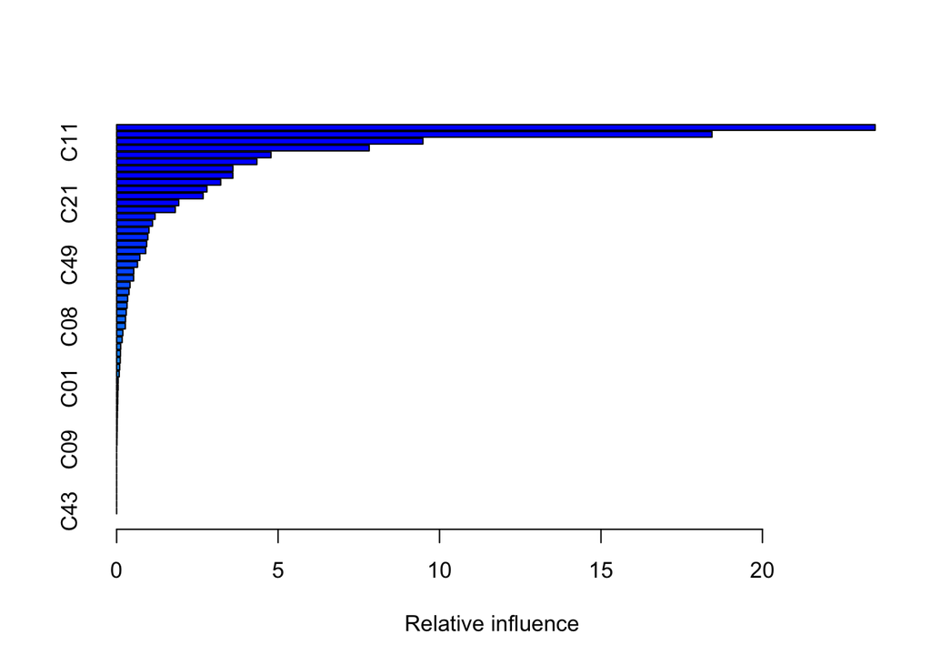

```
##     var      rel.inf
## C52 C52 23.490892467
## C10 C10 18.437475652
## C11 C11  9.485974372
## C57 C57  7.821147222
## C16 C16  4.780963388
## C53 C53  4.343360731
## C07 C07  3.602218616
## C55 C55  3.599561072
## C25 C25  3.222578610
## C19 C19  2.796307040
## C56 C56  2.678832830
## C21 C21  1.924447700
## C46 C46  1.816203928
## C24 C24  1.190174691
## C18 C18  1.112131157
## C12 C12  1.002137412
## C03 C03  0.966568196
## C50 C50  0.929477427
## C27 C27  0.900530188
## C05 C05  0.717652468
## C49 C49  0.646730112
## C45 C45  0.530617388
## C42 C42  0.525130575
## C37 C37  0.414501988
## C02 C02  0.384474356
## C36 C36  0.341406780
## C23 C23  0.323256349
## C38 C38  0.298819047
## C14 C14  0.276087164
## C08 C08  0.267933628
## C17 C17  0.193469993
## C06 C06  0.171308495
## C13 C13  0.126124684
## C44 C44  0.118870834
## C54 C54  0.112018923
## C20 C20  0.093728482
## C28 C28  0.080353377
## C47 C47  0.047898121
## C01 C01  0.046677582
## C04 C04  0.038085784
## C51 C51  0.035776186
## C30 C30  0.027815375
## C22 C22  0.023427052
## C41 C41  0.018447772
## C33 C33  0.017473151
## C48 C48  0.012060082
## C26 C26  0.008871552
## C09 C09  0.000000000
## C15 C15  0.000000000
## C29 C29  0.000000000
## C31 C31  0.000000000
## C32 C32  0.000000000
## C34 C34  0.000000000
## C35 C35  0.000000000
## C39 C39  0.000000000
## C40 C40  0.000000000
## C43 C43  0.000000000
```

```r
summary(mod.gbm)
```

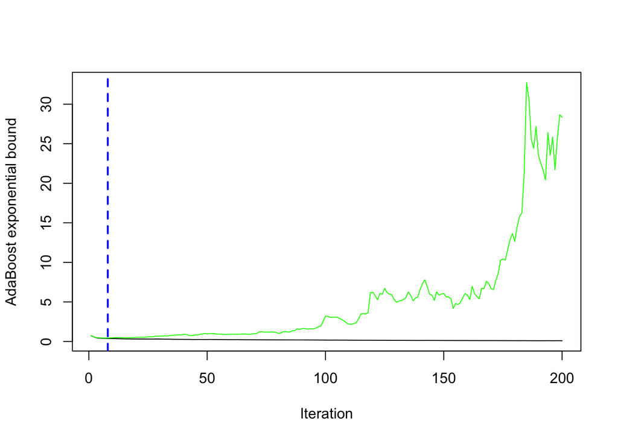

```
## [1] 8
```

```r
mod.gbm.cv <- gbm(class ~ .,
                  data=train.df,
                  distribution="adaboost",
                  shrinkage=theShrinkage,
                  n.trees=numTrees,
                  interaction.depth = theDepth,
                  cv.folds = 10)
gbm.perf(mod.gbm.cv)
```

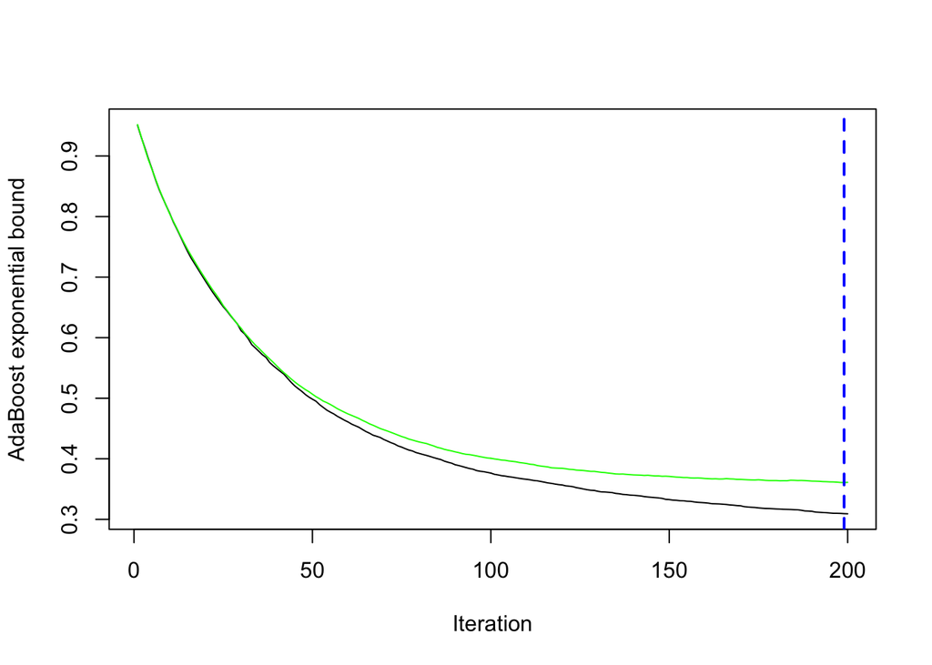

```
## [1] 199
```

```r
theShrinkage <- 0.05
mod.gbm.cv <- gbm(class ~ .,
                  data=train.df,
                  distribution="adaboost",
                  shrinkage=theShrinkage,
                  n.trees=numTrees,
                  interaction.depth = theDepth,
                  cv.folds = 10)
(numTreesOpt <- gbm.perf(mod.gbm.cv))
```

#See how this work with opt tree number

```r
mod.gbm <- gbm(class ~ .,
               data=train.df,
               distribution="adaboost",
               shrinkage=theShrinkage,
               n.trees=numTreesOpt,
               interaction.depth = theDepth)
prob.gbm <- predict(mod.gbm,
                    newdata=test.df,
                    n.trees=numTreesOpt,
                    type="response")
pred.gbm <- ifelse(prob.gbm > 0.5,1,0)
(err.gbm <- with(test.df,mean(class != pred.gbm)))
```

```
## [1] 0.0673913
```

```r
cvADA <- function(data.df,theShrinkage,theDepth,numTrees,numFolds=5){
  n <- nrow(data.df)
  folds <- sample(1:numFolds,n,rep=T)
  errs <- numeric(numFolds)
  for(fold in 1:numFolds){
    train.df <- data.df[folds != fold,]
    test.df <- data.df[folds == fold,]
    mod.gbm <- gbm(class ~ .,
                   data=train.df,
                   interaction.depth = theDepth,
                   distribution="adaboost",
                   shrinkage=theShrinkage,
                   n.trees=numTrees)
    prob.gbm <- predict(mod.gbm,
                        newdata=test.df,
                        n.trees=numTrees,type="response")
    errs[fold] <- with(test.df,mean((class == 1) != (prob.gbm > 0.5)))
    with(test.df,table((class),(prob.gbm > 0.5)))
  }
  print(errs)
  mean(errs)
}
```

```r
shrinkVals <- c(0.005,0.001,0.05,0.1,0.5)
depthVals <- c(2,3,4,5)
gridVals <- expand.grid(shrinkVals,depthVals)
calcErr <- function(shrink,depth){
  mod.gbm <- gbm(class ~ .,
                 data=train.df,
                 distribution="adaboost",
                 shrinkage=shrink,
                 n.trees=2*numTreesOpt,
                 interaction.depth = depth)
  prob.gbm <- predict(mod.gbm,
                      newdata=test.df,
                      n.trees=numTreesOpt,
                      type="response")
  pred.gbm <- ifelse(prob.gbm > 0.5,1,0)
  with(test.df,mean(class != pred.gbm))
}

##Test it out
calcErr(theShrinkage,theDepth)
```

```
## [1] 0.06173913
```

```r
gridErrs <- apply(gridVals,1,function(row) calcErr(row[1],row[2]))
id <- which.min(gridErrs)
(bestVals <- gridVals[id,])
```

```
##    Var1 Var2
## 20  0.5    5
```

```r
shrinkOpt <- bestVals[1]
depthOpt <- bestVals[2]
```

Then lets see our optimal mse value for boosting

```r
(mse.ada <- cvADA(spam.df1,shrinkOpt, depthOpt, numTreesOpt))
```

```
## [1] 0.04932735 0.05851064 0.05005688 0.04923077 0.04704595
```

```
## [1] 0.05083432
```

```r
err.ada <- mse.ada
```

```r
c(err.ada,err.ridge,err.lasso,err.log)
```

```
## [1] 0.05083432 0.07369565 0.07521739 0.07397616
```

As we can see, ADA boosting is winning a lot here.